# Lab5DennysLaquintaPt2

Tarak Patel

10/16/2021

### Load packages and state data

```r
library(tidyverse)
library(dsbox)
library(here)
library(readxl)
```

```r
states <- read_excel(here("data","raw","states.xlsx"))
```

### Exercise 1: Filter the Denny’s dataframe for Alaska (AK) and save the result as dn_ak. How many Denny’s locations are there in Alaska?

```r
dn_ak <- dennys %>%
  filter(state == "AK")
nrow(dn_ak)
```

```
[1] 3
```

There are 3 Denny’s locations in Alaska.

### Exercise 2: Filter the La Quinta dataframe for Alaska (AK) and save the result as lq_ak. How many La Quinta locations are there in Alaska?

```r
lq_ak <- laquinta %>%
  filter(state == "AK")
nrow(lq_ak)
```

```
[1] 2
```

There are 2 La Quinta locations in Alaska.

### Exercise 3: How many pairings are there between all Denny’s and all La Quinta locations in Alaska, i.e. how many distances do we need to calculate between the locations of these establishments in Alaska?

There are 6 pairings between all Denny’s and all La Quinta locations in Alaska. Therefore we need to calculate a total of 6 distances. To do this we will need to join 2 Denny’s and La Quinta data frames.

```r
dn_lq_ak <- full_join(dn_ak, lq_ak, by = "state")
dn_lq_ak
```

| address.x | city.x | state | zip.x | longitude.x | latitude.x | establishment.x | address.y | city.y | zip.y | longitude.y | latitude.y | establishment.y |
| --- | --- | --- | --- | --- | --- | --- | --- | --- | --- | --- | --- | --- |
| 2900 Denali | Anchorage | AK | 99503 | -149.8767 | 61.1953 | Denny's | 3501 Minnesota Dr. | \nAnchorage | 99503 | -149.9119 | 61.18843 | La Quinta |
| 2900 Denali | Anchorage | AK | 99503 | -149.8767 | 61.1953 | Denny's | 4920 Dale Rd | \nFairbanks | 99709 | -147.8660 | 64.82426 | La Quinta |
| 3850 Debarr Road | Anchorage | AK | 99508 | -149.8090 | 61.2097 | Denny's | 3501 Minnesota Dr. | \nAnchorage | 99503 | -149.9119 | 61.18843 | La Quinta |
| 3850 Debarr Road | Anchorage | AK | 99508 | -149.8090 | 61.2097 | Denny's | 4920 Dale Rd | \nFairbanks | 99709 | -147.8660 | 64.82426 | La Quinta |
| 1929 Airport Way | Fairbanks | AK | 99701 | -147.7600 | 64.8366 | Denny's | 3501 Minnesota Dr. | \nAnchorage | 99503 | -149.9119 | 61.18843 | La Quinta |
| 1929 Airport Way | Fairbanks | AK | 99701 | -147.7600 | 64.8366 | Denny's | 4920 Dale Rd | \nFairbanks | 99709 | -147.8660 | 64.82426 | La Quinta |

This performs a full join on the Denny’s and La Quinta data by state.

### Exercise 5: What function from the tidyverse do we use the add a new variable to a data frame while keeping the existing variables?

From the tidyverse, we use the mutate function. To calculate the distances we need to declare a function that is not found in R.

```r
haversine <- function(long1, lat1, long2, lat2, round = 3) {
  # convert to radians
  long1 = long1 * pi / 180
  lat1  = lat1  * pi / 180
  long2 = long2 * pi / 180
  lat2  = lat2  * pi / 180

  R = 6371 # Earth mean radius in km

  a = sin((lat2 - lat1)/2)^2 + cos(lat1) * cos(lat2) * sin((long2 - long1)/2)^2
  d = R * 2 * asin(sqrt(a))

  return( round(d,round) ) # distance in km
}
```

### Exercise 6: Calculate the distances between all pairs of Denny’s and La Quinta locations and save this variable as distance. Make sure to save this variable in THE dn_lq_ak data frame so that you can use it later.

Using the mutate function we add a distance variable to the fully joined data frame.

```r
dn_lq_ak=dn_lq_ak %>%
  mutate(distance=
           haversine(longitude.x, latitude.x, longitude.y, latitude.y, round = 4))
```

### Exercise 7: Calculate the minimum distance between a Denny’s and La Quinta for each Denny’s location. To do so we group by Denny’s locations and calculate a new variable that stores the information for the minimum distance.

```r
dn_lq_ak_mindist <- dn_lq_ak %>%
  group_by(address.x) %>%
  summarise(closest = min(distance))
```

### Exercise 8: Describe the distribution of the distances Denny’s and the nearest La Quinta locations in Alaska. Also include an appripriate visualization and relevant summary statistics.

```r
summary(dn_lq_ak_mindist)
```

```
  address.x            closest
 Length:3           Min.   :2.035
 Class :character   1st Qu.:3.616
 Mode  :character   Median :5.197
                    Mean   :4.410
                    3rd Qu.:5.598
                    Max.   :5.998
```

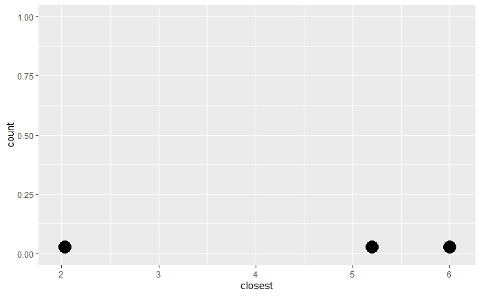

```r
dn_lq_ak_mindist %>% ggplot(aes(x=closest)) + geom_dotplot()
```

### Exercise 9: Repeat the same analysis for North Carolina: (i) filter Denny’s and La Quinta Data Frames for NC, (ii) join these data frames to get a completelist of all possible pairings, (iii) calculate the distances between all possible pairings of Denny’s and La Quinta in NC, (iv) find the minimum distance between each Denny’s and La Quinta location, (v) visualize and describe the distribution of these shortest distances using appropriate summary statistics.

```r
dn_nc <- dennys %>%
  filter(state == "NC")
lq_nc <- laquinta %>%
  filter(state == "NC")
dn_lq_nc <- full_join(dn_nc, lq_nc, by = "state")
dn_lq_nc=dn_lq_nc %>%
  mutate(distance=
           haversine(longitude.x, latitude.x, longitude.y, latitude.y, round = 4))
dn_lq_nc_mindist <- dn_lq_nc %>%
  group_by(address.x) %>%
  summarise(closest = min(distance))
summary(dn_lq_nc_mindist)
```

```
  address.x            closest
 Length:28          Min.   :  1.779
 Class :character   1st Qu.: 22.388
 Mode  :character   Median : 53.457
                    Mean   : 65.444
                    3rd Qu.: 93.985
                    Max.   :187.935
```

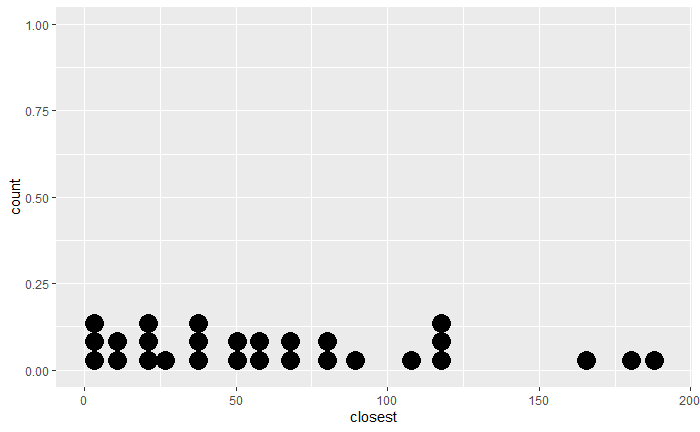

```r
dn_lq_nc_mindist %>% ggplot(aes(x=closest)) + geom_dotplot()
```

### Exercise 10: Repeat the same analysis for Texas.

```r
dn_tx <- dennys %>%
  filter(state == "TX")
lq_tx <- laquinta %>%
  filter(state == "TX")
dn_lq_tx <- full_join(dn_tx, lq_tx, by = "state")
dn_lq_tx=dn_lq_tx %>%
  mutate(distance=
           haversine(longitude.x, latitude.x, longitude.y, latitude.y, round = 4))
dn_lq_tx_mindist <- dn_lq_tx %>%
  group_by(address.x) %>%
  summarise(closest = min(distance))
summary(dn_lq_tx_mindist)
```

```
  address.x            closest
 Length:200         Min.   : 0.0163
 Class :character   1st Qu.: 0.7306
 Mode  :character   Median : 3.3715
                    Mean   : 5.7918
                    3rd Qu.: 6.6302
                    Max.   :60.5821
```

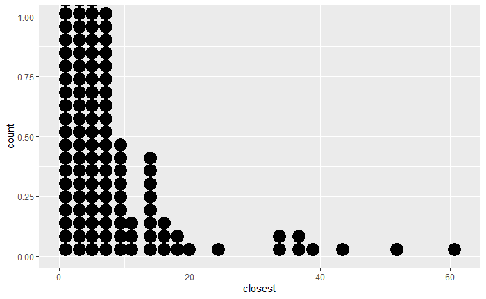

```r
dn_lq_tx_mindist %>% ggplot(aes(x=closest)) + geom_dotplot()
```

### Exercise 11: Repeat the same analysis for a state of your choosing, different than the ones we covered so far.

State Chosen: Georgia

```r
dn_ga <- dennys %>%
  filter(state == "GA")
lq_ga <- laquinta %>%
  filter(state == "GA")
dn_lq_ga <- full_join(dn_ga, lq_ga, by = "state")
dn_lq_ga=dn_lq_ga %>%
  mutate(distance=
           haversine(longitude.x, latitude.x, longitude.y, latitude.y, round = 4))
dn_lq_ga_mindist <- dn_lq_ga %>%
  group_by(address.x) %>%
  summarise(closest = min(distance))
summary(dn_lq_ga_mindist)
```

```
  address.x            closest
 Length:22          Min.   : 0.0242
 Class :character   1st Qu.: 0.6778
 Mode  :character   Median : 7.7063
                    Mean   :14.0458
                    3rd Qu.:13.8812
                    Max.   :73.1200
```

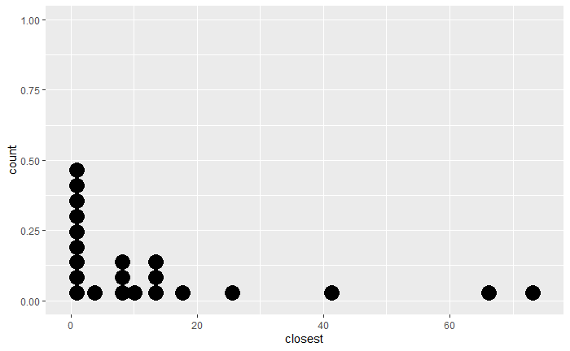

```r
dn_lq_ga_mindist %>% ggplot(aes(x=closest)) + geom_dotplot()
```

### Exercise 12: Among the states you examined, where is Mitch Hedberg’s joke most likely to hold true? Explain your reasoning.

Among the states examined and analyzed, Mitch Hedberg’s joke is most likely to hold true in the state of Texas because the visualization by Texas showed an abundance of locations where there were a Denny’s and La Quinta close by.